# Homework 4

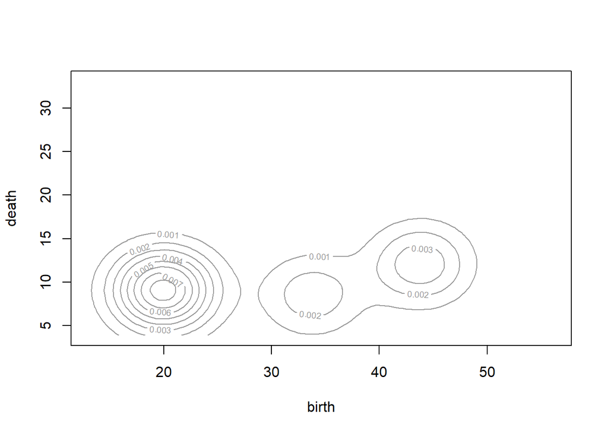

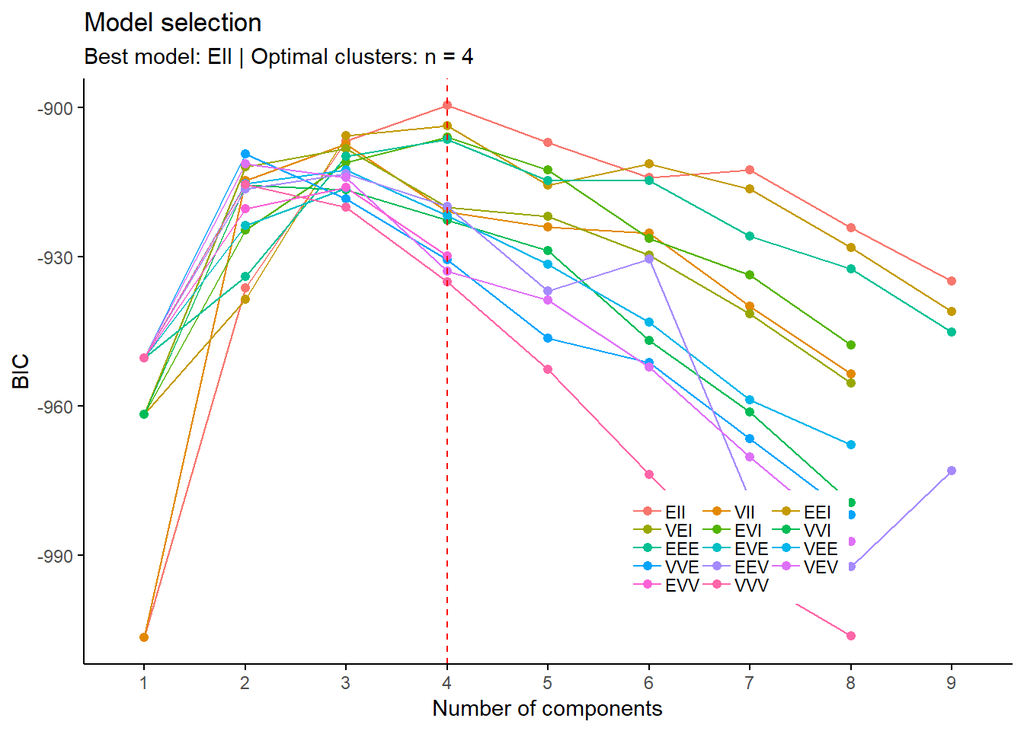

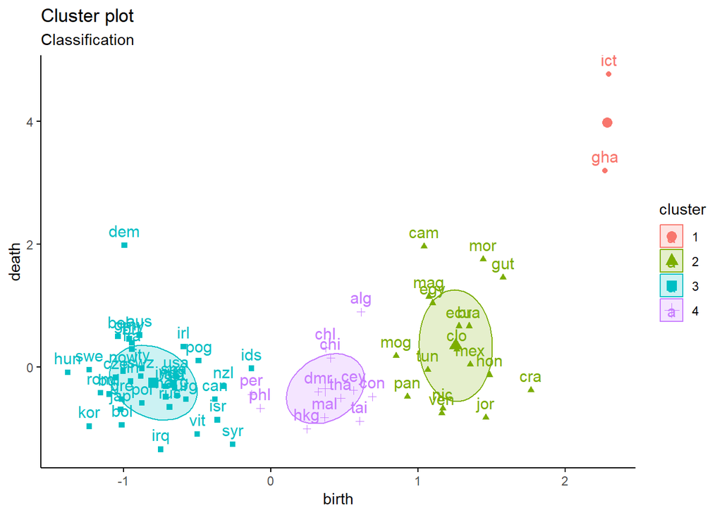

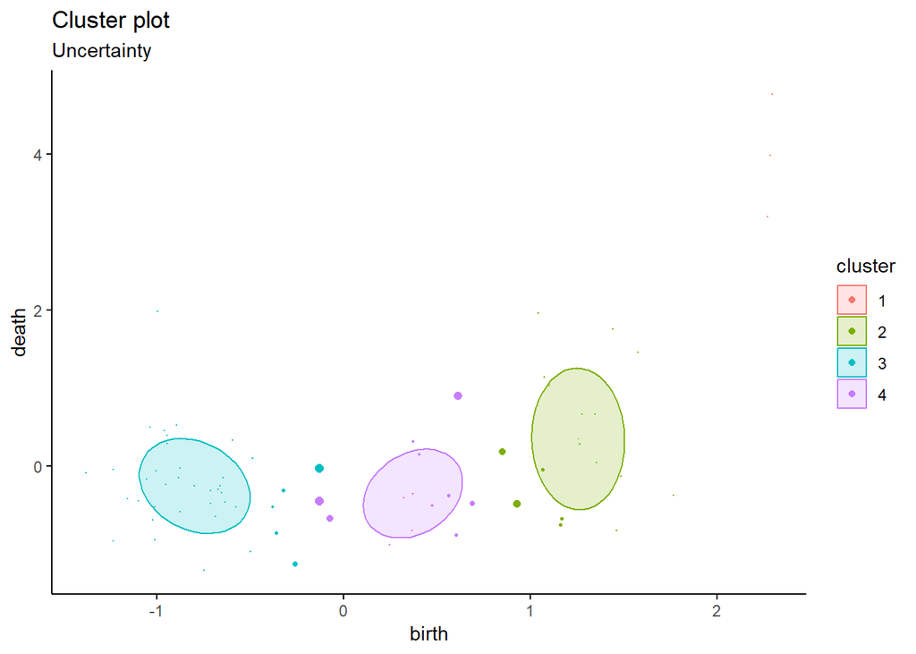

```
e.) Discuss the results (structure of data, outliers, etc.). Write a discussion in the context of the problem.
```

# My Thoughts: The data was structured as birth rate vs death rate with density as the y axis. 4 clusters were found by the EM algorithm with means around birth rate of 55.94967 43.80396 19.922913 33.730672 and means around death rate of 29.34960 12.09411 9.081348 8.535812 (the four numbers for birth and death make a coordinate with each other for each of the four numbers in the sequnce). The two best models based on BIC score had 4 clusters, confirming this finding. The cluster plots show all 4 components for “classification” but not for uncertainty. The library factoextra visualizes the cluster better than the base r plot in my opinion. The line plot with BIC scores is allso a nice visualization of how different (or not different) the scores are for models with different components. What this data shows is basically the replacement rate (without accounting for immigration/emmigration),when birth is higher than death you grow and vice versa.This clustering shows countries that may be shrinking some that are stagnant and some that may be growing, but it allows us to gain o what countries will be a population growth center.

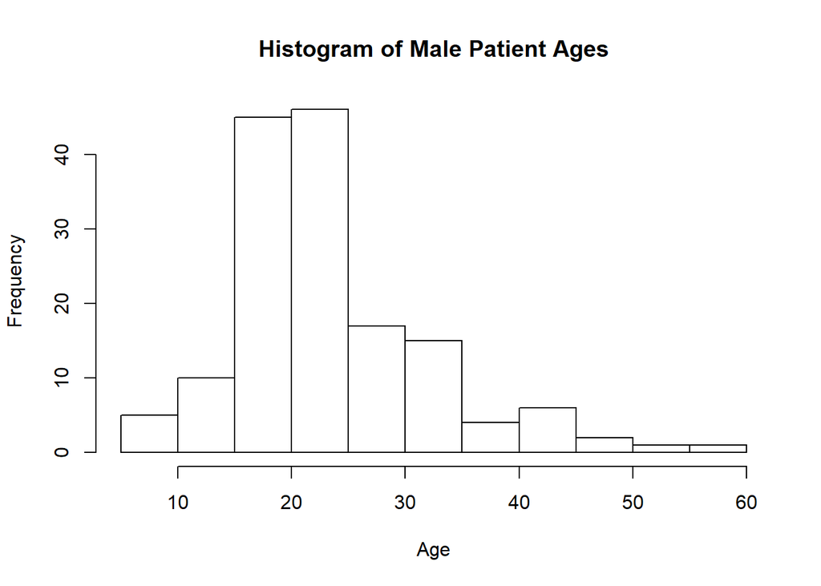

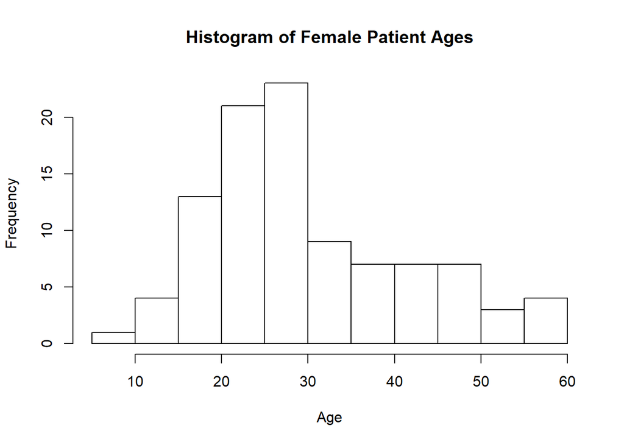

[figure not shown]

# My Thoughts: Based on the data available (~150 males and ~100 females) it appears males are diagnosed at younger ages, peaking around 20 while females are at the peak for being diagnosed later between 25 and 30.

```
## ----------------------------------------------------
## Gaussian finite mixture model fitted by EM algorithm
## ----------------------------------------------------
##
## Mclust E (univariate, equal variance) model with 2 components:
##
##  log-likelihood   n df       BIC       ICL
##       -912.8923 251  4 -1847.886 -1864.194
##
## Clustering table:
##   1   2
## 213  38
##
## Mixing probabilities:
##         1         2
## 0.8390524 0.1609476
##
## Means:
##        1        2
## 22.90064 45.27658
##
## Variances:
##        1        2
## 40.66788 40.66788
```

```
## Bayesian Information Criterion (BIC):
##           E         V
## 1 -1899.227 -1899.227
## 2 -1847.886 -1850.526
## 3 -1859.118 -1861.375
## 4 -1870.313 -1871.969
## 5 -1878.766 -1887.347
## 6 -1889.716        NA
## 7 -1886.809        NA
## 8 -1897.890        NA
## 9 -1908.955        NA
##
## Top 3 models based on the BIC criterion:
##       E,2       V,2       E,3
## -1847.886 -1850.526 -1859.118
```

# My Thoughts: When we cluster without separating for gender, we find there are two clusters, one around 22 and one around 45 years old. This may be different if we cluster after separating by gender.

```
## ----------------------------------------------------
## Gaussian finite mixture model fitted by EM algorithm
## ----------------------------------------------------
##
## Mclust V (univariate, unequal variance) model with 2 components:
##
##  log-likelihood   n df       BIC       ICL
##       -520.9747 152  5 -1067.069 -1134.392
##
## Clustering table:
##  1  2
## 99 53
##
## Mixing probabilities:
##         1         2
## 0.5104189 0.4895811
##
## Means:
##        1        2
## 20.23922 27.74615
##
## Variances:
##          1          2
##   9.395305 111.997525
```

# My Thoughts: We now see that males have different clusters than the mixed population. Males have a cluster at ~20 years old and ~28 years old, much younger than the cluster in the 40s for the mixed population.

```
## ----------------------------------------------------
## Gaussian finite mixture model fitted by EM algorithm
## ----------------------------------------------------
##
## Mclust E (univariate, equal variance) model with 2 components:
##
##  log-likelihood  n df       BIC       ICL
##       -373.6992 99  4 -765.7788 -774.8935
##
## Clustering table:
##  1  2
## 74 25
##
## Mixing probabilities:
##         1         2
## 0.7472883 0.2527117
##
## Means:
##        1        2
## 24.93517 46.85570
##
## Variances:
##        1        2
## 44.55641 44.55641
```

# My Thoughts: When we evaluate the females without the males we see a larger spread in clusters than the men with clusters at ~25 years old and ~47 years old.

```
## [1] "Male Density"
```

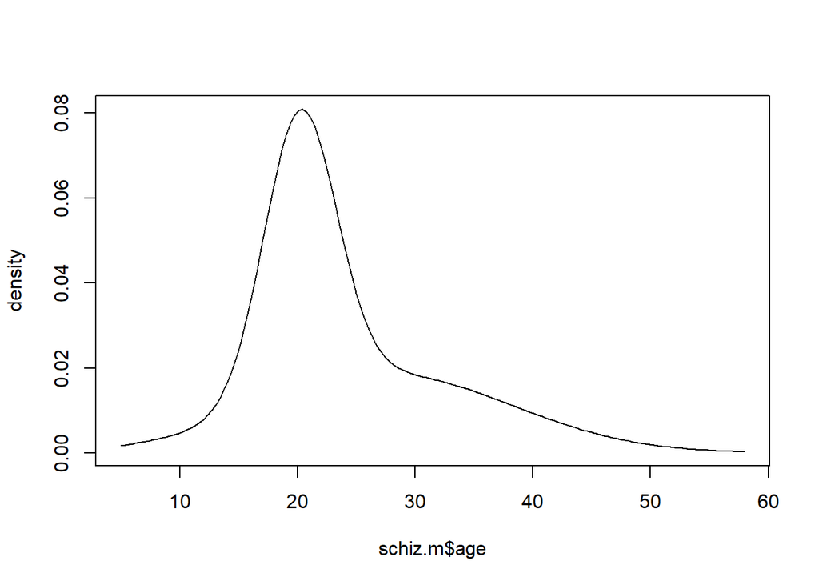

```
## [1] "Female Density"
```

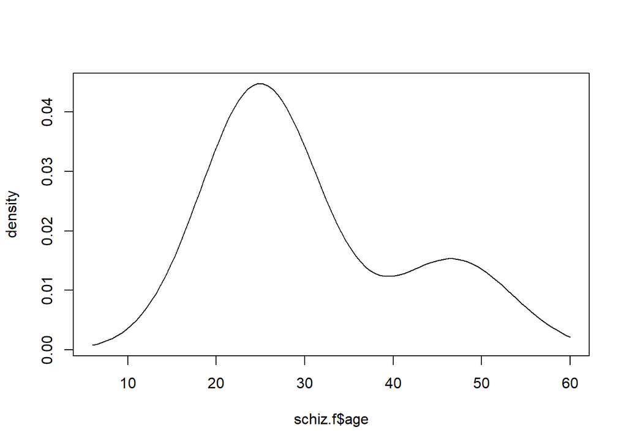

# My Thoughts: We see that the distribution of diagnosis with schizophrenia is more unimodal in men and bimodal in women. Both men and women are highly diagnosed in their early to mid twenties but there is a second age of high diagnosis for women in their late 40s. I would say this means both men and women are at risk in their early twenties and women are at higher risk again in late 40s but this may be due to low sample size. A larger sample size may create a more unimodal distribution for women.